# visTimeEvent package

# Description

This package provides functions for creating Kaplan-Meier and cumulative incidence plots. These functions serve as wrappers for ggsurvfit() and cuminc(), allowing for the quick generation of well-formatted visualizations. Users can choose to display the median time-to-event probability, median cumulative incidence, or event probability at a specific timepoint along with corresponding confidence intervals. When comparing two groups, the plot includes the p-value from the appropriate hypothesis test for assessing differences between them.

Following functions are available:

- Kaplan-Meier curves:
  - `km_single`: This function plots the Kaplan-Meier curve for a single group.
  - `km_grouped`: This function plots the Kaplan-Meier curve stratified by two groups. The p-value from the log-rank or Wilcoxon test is included in the plot.
  - `km_grouped_weighted`: This function plots weighted Kaplan-Meier curves for two groups, using weights such as those from Propensity Score Inverse Probability of Treatment Weighting (IPTW) or other methods. The p-value from the stratified log-rank test is also displayed.
- Cumulative incidence curves:
  - `comp_risk_single`: This function plots the cumulative incidence curves for competing events.
  - `comp_risk_grouped`: This function Plots cumulative incidence curves for two groups with competing events, showing only the first event. The p-value for comparing the curves is also displayed.

# Examples

```r
library(visTimeEvent)
library(survival)
library(dplyr)
```

## Kaplan-Meier curves

```r
test_dat <- survival::pbc
test_dat <- test_dat %>%
  mutate(status_death = ifelse(status == 2, 1, 0),
         status_death = as.integer(status_death),
         time = time/365,
         trt = as.factor(ifelse(trt == 1, "treatment", "placebo")),
         trt_num = ifelse(trt == "treatment", 1, 0),
         status = as.factor(status)) %>%
  filter(!is.na(trt))
```

```r
plot_km <- km_single(
  data = test_dat,
  time = "time",
  event = "status_death",
  title = "Kaplan-Meier curves for one group",
  unit = "years",
  endpoint = "OS",
  colors = "darkblue",
  show_label = "median"
)
```

```
#> [1] "Following options were chosen: "
#> [1] "- time-to-event probability of 1 years"
```

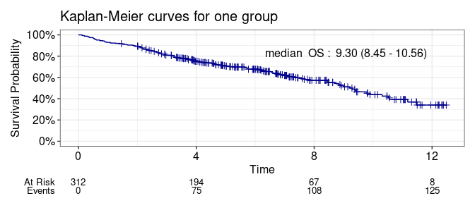

```r
plot_km[[1]]
```

```r
plot_km1 <- km_grouped(
  data = test_dat,
  time = "time",
  event = "status_death",
  group = "trt",
  time_survival = 6,
  #test = "wilcoxon",
  title = "Kaplan-Meier curves for two groups",
  unit = "years",
  endpoint = "OS",
  colors = c("darkblue", "darkgreen"),
  show_label = "probability"
)
```

```
#> [1] "Following options were chosen: "
#> [1] "- significance test: log-rank"
#> [1] "- time-to-event probability of 6 years"
#> Call: survfit(formula = formula, data = data)
#>
#>                 trt=placebo
#>         time       n.risk      n.event     survival      std.err lower 95% CI
#>       6.0000      65.0000      44.0000       0.6950       0.0391       0.6225
#> upper 95% CI
#>       0.7760
#>
#>                 trt=treatment
#>         time       n.risk      n.event     survival      std.err lower 95% CI
#>       6.0000      65.0000      48.0000       0.6613       0.0407       0.5861
#> upper 95% CI
#>       0.7462
```

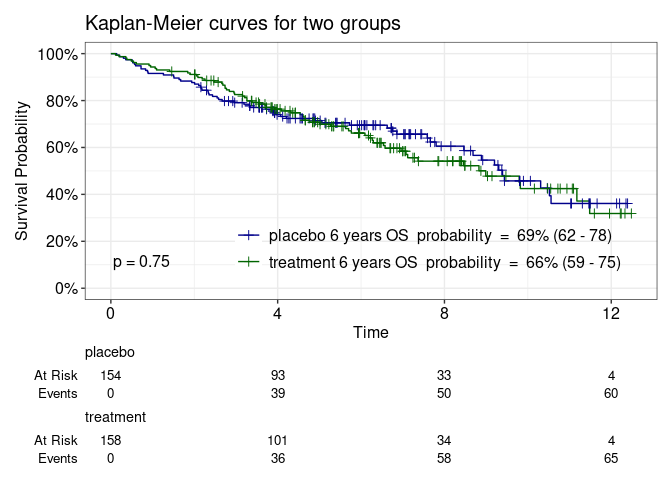

```r
plot_km1[[1]]
```

## Weighted Kaplan-Meier curves

```r
library(WeightIt)

test_dat_iptw <- test_dat %>%
  filter_at(vars(sex, platelet, trig, age), all_vars(!is.na(.)))

weight_obj <- weightit(trt_num ~ sex + platelet + trig + age,
  data = test_dat_iptw,
  method = "glm"
)

test_dat_iptw$weights <- weight_obj$weights

test_dat_iptw <- test_dat_iptw %>%
  mutate(trt = as.factor(if_else(trt == "placebo", 0, 1)))

plot_km_iptw <- km_grouped_weighted(
  data = test_dat_iptw,
  time = "time",
  event = "status_death",
  group = "trt",
  weight_col = "weights",
  group_name = c("treatment", "placebo"),
  endpoint = "OS",
  title = "Weighted KM- curves with two groups",
  unit = "years",
  show_label = "probability",
  time_survival = 6,
  x_lim = c(0, 14),
  x_breaks = c(0, 2, 4, 6, 8, 12, 14),
  risk_table = TRUE,
  color_curves = c("darkgreen", "deepskyblue3"),
  legend_placement = c(0.6, 0.2)
)
```

```
#> [1] "Risk table" "0"          "5"          "10"         NA
#> [1] "Risk table" "-0.7"       "14.7"
```

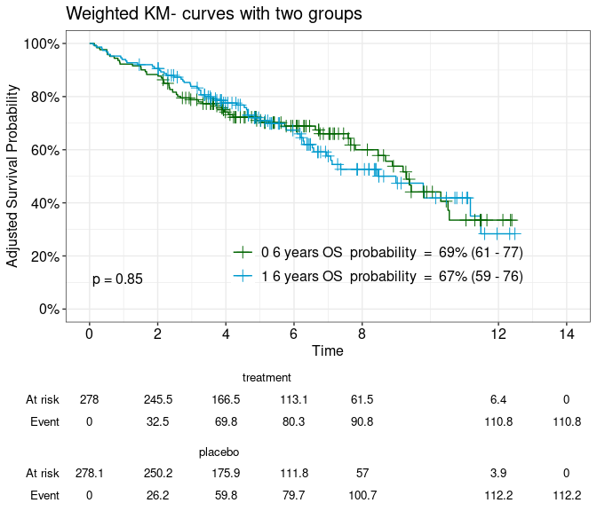

```r
plot_km_iptw[[1]]
```

## Cumulative incidence curves

Plotted are both competing events

```r
plot_cum <- comp_risk_single(
  data = test_dat,
  time = "time",
  event = "status",
  title = "Competing risk of a single group",
  unit = "years",
  colors = c("darkred", "darkblue"),
  show_label = "probability",
  time_survival = 8
)
```

```
#> [1] "1" "2"
#> [1] 2
```

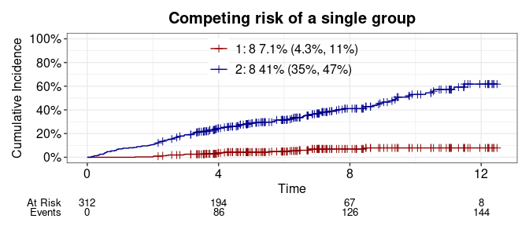

```r
plot_cum[[1]]
```

Plotted are the competing event labeled with 1

```r
plot_cum1 <- comp_risk_grouped(
  data = test_dat,
  time = "time",
  event = "status",
  group = "trt",
  title = "Competing risk of two group",
  unit = "years",
  colors = c("darkgreen", "deepskyblue3"),
  show_label = "probability",
  time_survival = 8
)
```

```
#> Surv(time, status) ~ trt
#> <environment: 0x5571a6e6bd20>
#> Plotting outcome "1".
```

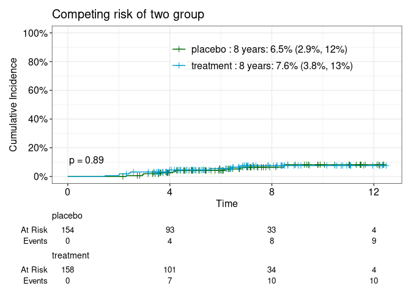

```r
plot_cum1[[1]]
```